# Predicting World Happiness for year 2023 using Data Analysis

# Bar plot is used to visualize the distribution of categorical variable Country with continuous variable Happiness Score for top 10 Happiest Countries in the world.

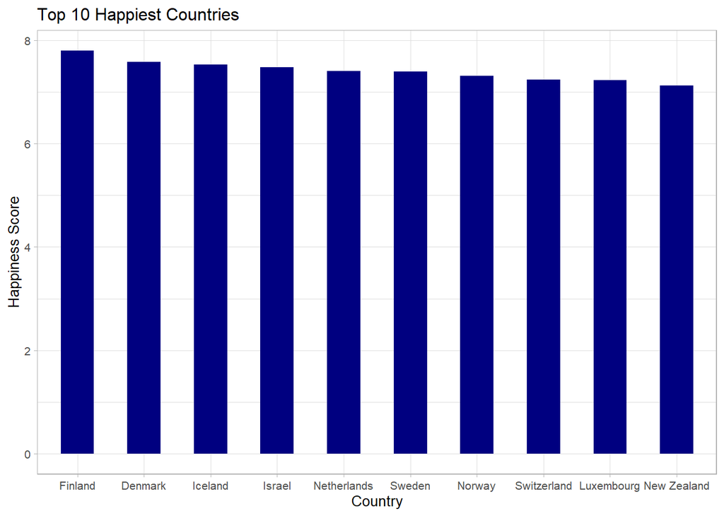

```r
ggplot(Top_10_Happiest_Country,aes(x=factor(Country,levels=Country),y=Happiness_score))+
  geom_bar(stat="identity",width=0.5,fill="navyblue")+
  theme(axis.text.x = element_text(angle=90, vjust=0.6))+
  theme_light(base_size = 10)+
  labs(title="Top 10 Happiest Countries",x="Country",y="Happiness Score")
```

> This plot can help us compare the happiness scores of different countries and understand which countries have the highest levels of happiness.

# 2. EDA for some predictor variables like Life Expectancy, Freedom against target variable Happiness Score.

# 2.a. Happiness Score & Life Expectency

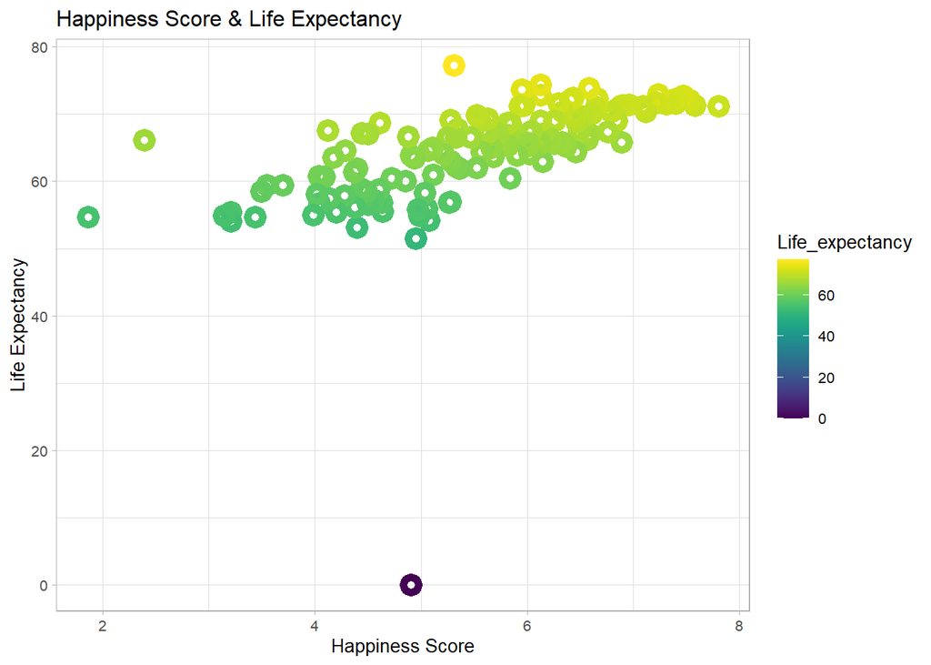

```r
library(ggplot2)
library(viridis)
ggplot(data = data, aes(x = Happiness_score, y =  Life_expectancy)) +
  geom_point(aes(color = Life_expectancy), show.legend = T, pch=1, stroke=3, size = 2) +
  theme_light(base_size = 10) + scale_color_viridis(discrete = F) +
  labs(title = "Happiness Score & Life Expectancy", fill = "Happiness Score",
       x = "Happiness Score" , y = "Life Expectancy")
```

> We are using scatter plot to investigate the distribution between 2 continuous variable Happiness score and Life expectancy where each point represents a country.This plot shows that there appears to be a pretty significant relationship between Life Expectancy and the happiness score as the data points appear to show a positive trend.

# 2.d. Happiness Score & Freedom

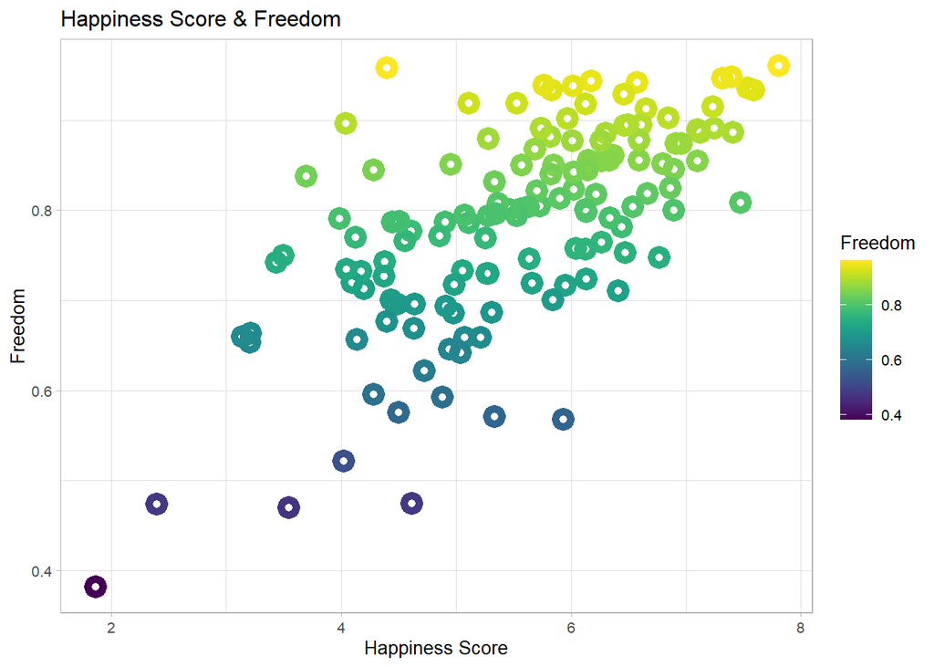

```r
ggplot(data = data, aes(x = Happiness_score, y =  Freedom)) +
  geom_point(aes(color = Freedom), show.legend = T, pch=1, stroke=3, size = 2) +
  theme_light(base_size = 10) + scale_color_viridis(discrete = F) +
  labs(title = "Happiness Score & Freedom", fill = "Happiness Score",
       x = "Happiness Score" , y = "Freedom")
```

> As predicted this plot shows that as freedom increases so does the happiness score, but we do not know if this relationship is causal and there may be confounds.

# 3. Happiness Score & Region

# 3.a. Regionwise Happiness score using overlay barplot

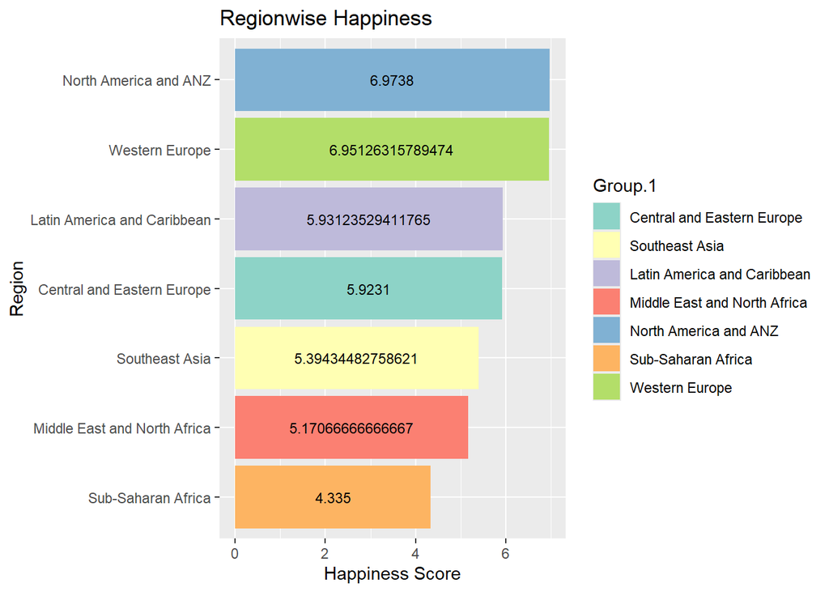

```r
data_means <- aggregate(dataRegion$Happiness_score, list(dataRegion$Region), mean)

data_means %>% arrange(desc(x)) %>% ggplot(aes(x = x, y = reorder(Group.1, x),  fill = Group.1)) +
  geom_bar(stat = "identity") +
  labs(title = "Regionwise Happiness") +
  ylab("Region") +
  xlab("Happiness Score") +
  scale_fill_brewer(palette = "Set3") +
  geom_text(aes(label = x), position=position_stack(vjust=0.5),color="black",size=3)
```

> The above barplot gives the region wise Happiness Score from highest to lowest.

# 3.b. Happiness score and Region overlay histogram

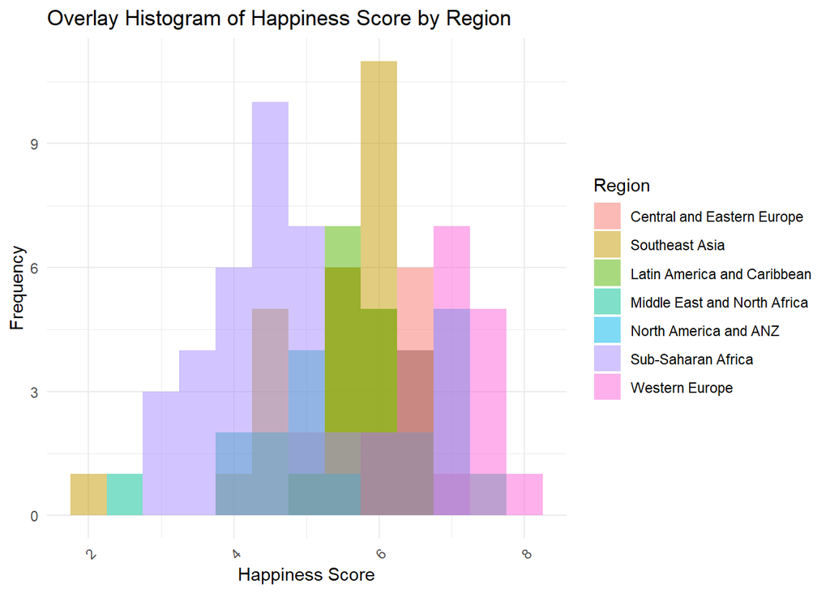

```r
# Create the histogram using ggplot2
ggplot(dataRegion, aes(x = Happiness_score, fill = Region)) +
  geom_histogram(binwidth = 0.5, alpha = 0.5, position = "identity") +
  theme_minimal() +
  labs(title = "Overlay Histogram of Happiness Score by Region", x = "Happiness Score", y = "Frequency") +
  theme(axis.text.x = element_text(angle = 45, hjust = 1))
```

# 5. Exploratory data analysis of Region with other variables.

# Combine Regions to reduce number of categories

```r
dataRegionCat <- dataRegion %>%
  mutate(Region = fct_recode(Region,
                            # new name         old name
                            "Africa" = "Sub-Saharan Africa",
                            "ME"     = "Middle East and North Africa",
                            "N AMR"  = "North America and ANZ",
                            "CIS"    = "Commonwealth of Independent States",
                            "S AMR"  = "Latin America and Caribbean",
                            "SE Asia"= "Southeast Asia",
                            "EUR"    = "Central and Eastern Europe",
                            "EUR"    = "Western Europe" ))
#Reviewing the cropped names of Region column
dataRegionCat
```

| Country | Region | Happiness_score | GDP | Social_support | Life_expectancy | Freedom | Generosity | Corruption | Dystopia_residual |
| --- | --- | --- | --- | --- | --- | --- | --- | --- | --- |
| Finland | EUR | 7.804 | 10.792 | 0.969 | 71.150 | 0.961 | -0.019 | 0.182 | 2.363 |
| Denmark | EUR | 7.586 | 10.962 | 0.954 | 71.250 | 0.934 | 0.134 | 0.196 | 2.084 |
| Iceland | EUR | 7.530 | 10.896 | 0.983 | 72.050 | 0.936 | 0.211 | 0.668 | 2.250 |
| Israel | ME | 7.473 | 10.639 | 0.943 | 72.697 | 0.809 | -0.023 | 0.708 | 2.691 |
| Netherlands | EUR | 7.403 | 10.942 | 0.930 | 71.550 | 0.887 | 0.213 | 0.379 | 2.110 |
| Sweden | EUR | 7.395 | 10.883 | 0.939 | 72.150 | 0.948 | 0.165 | 0.202 | 1.903 |
| Norway | EUR | 7.315 | 11.088 | 0.943 | 71.500 | 0.947 | 0.141 | 0.283 | 1.829 |
| Switzerland | EUR | 7.240 | 11.164 | 0.920 | 72.900 | 0.891 | 0.027 | 0.266 | 1.870 |
| Luxembourg | EUR | 7.228 | 11.660 | 0.879 | 71.675 | 0.915 | 0.024 | 0.345 | 1.845 |
| New Zealand | N AMR | 7.123 | 10.662 | 0.952 | 70.350 | 0.887 | 0.175 | 0.271 | 1.852 |

[output cut: 127 more lines]

## Create a new factor variable called score

```r
library(dplyr)
library(tidyr)
# Create a New Factor Variable for Happiness

mn = min(dataRegionCat$Happiness_score)
mx = max(dataRegionCat$Happiness_score)
b = (mx - mn)/3.0
brk = seq(from = (mn-0.001), to = mx, by = b)

# create new categorical variable
dataRegionCat$Score <- cut(dataRegionCat$Happiness_score, breaks = brk,labels = c("Low", "Medium", "High"))
dataRegionCat <- dataRegionCat %>% drop_na()

#Reviewing Score column in dataset
dataRegionCat
```

| Country | Region | Happiness_score | GDP | Social_support | Life_expectancy | Freedom | Generosity | Corruption | Dystopia_residual | Score |
| --- | --- | --- | --- | --- | --- | --- | --- | --- | --- | --- |
| Denmark | EUR | 7.586 | 10.962 | 0.954 | 71.250 | 0.934 | 0.134 | 0.196 | 2.084 | High |
| Iceland | EUR | 7.530 | 10.896 | 0.983 | 72.050 | 0.936 | 0.211 | 0.668 | 2.250 | High |
| Israel | ME | 7.473 | 10.639 | 0.943 | 72.697 | 0.809 | -0.023 | 0.708 | 2.691 | High |
| Netherlands | EUR | 7.403 | 10.942 | 0.930 | 71.550 | 0.887 | 0.213 | 0.379 | 2.110 | High |
| Sweden | EUR | 7.395 | 10.883 | 0.939 | 72.150 | 0.948 | 0.165 | 0.202 | 1.903 | High |
| Norway | EUR | 7.315 | 11.088 | 0.943 | 71.500 | 0.947 | 0.141 | 0.283 | 1.829 | High |
| Switzerland | EUR | 7.240 | 11.164 | 0.920 | 72.900 | 0.891 | 0.027 | 0.266 | 1.870 | High |
| Luxembourg | EUR | 7.228 | 11.660 | 0.879 | 71.675 | 0.915 | 0.024 | 0.345 | 1.845 | High |
| New Zealand | N AMR | 7.123 | 10.662 | 0.952 | 70.350 | 0.887 | 0.175 | 0.271 | 1.852 | High |
| Austria | EUR | 7.097 | 10.899 | 0.888 | 71.150 | 0.855 | 0.102 | 0.497 | 2.124 | High |

[output cut: 126 more lines]

# 5.f. Region by Generosity

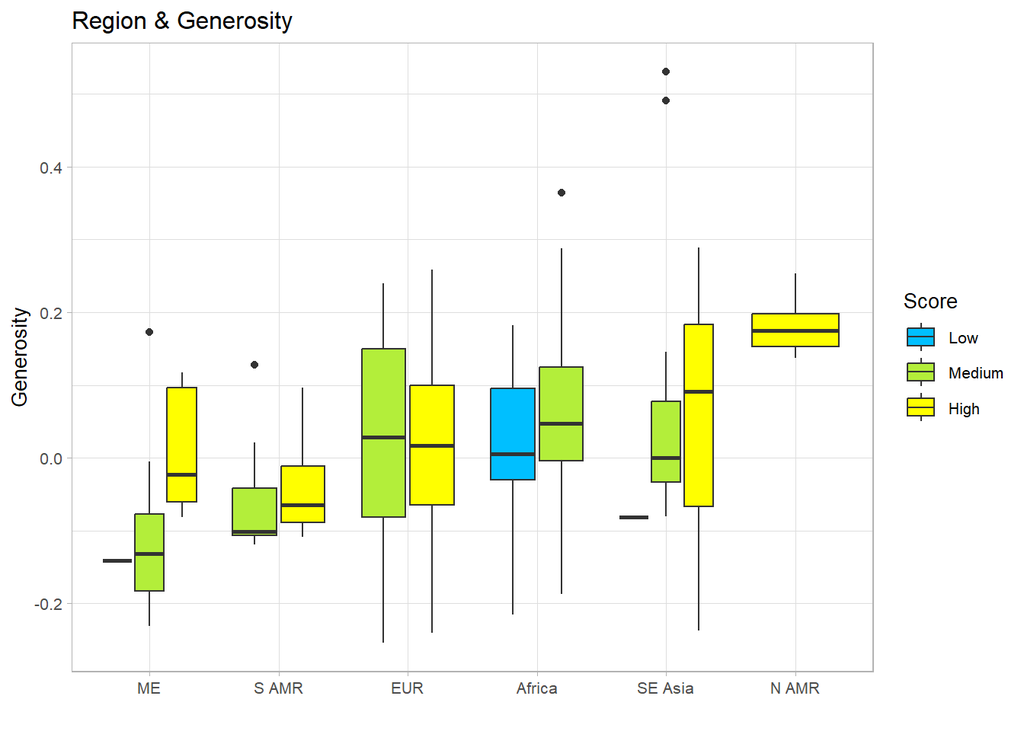

```r
ggplot(data = dataRegionCat, aes(x = reorder(Region, Generosity),
                     y = Generosity, fill = Score)) +
  geom_boxplot(show.legend = T) +
  labs(x = "", fill = "Score", y = "Generosity",
       title = "Region & Generosity") +
  scale_fill_manual(values = c("deepskyblue","olivedrab2", "yellow")) +
  theme_light(base_size = 10)
```

> Overall, this plot suggests that generosity varies significantly across regions and may be related to regional differences in happiness scores.

# STEP 7 : HYPOTHESIS TEST :

# The target variable Happiness score is slightly skewed as discussed above and follows nearly a normal distribution, so we will be using T-statistic instead of Z-statisitc.